# Lab 2: Data Understanding & Exploratory Data Analysis

CRISP-DM Phase 2 — Carseats Case

Author

Prof. Dr. Jörg Schoder

Published

March 20, 2026

## 1 Learning Objectives and Overview

**NoteLearning Objectives**

- Explore the Carseats dataset: structure, variable types, distributions
- Understand EDA as **descriptive** and **inductive** — and know what follows from this
- Visualise bivariate relationships and formulate hypotheses for modelling
- Establish EDA as a mandatory first step before any regression analysis

**Scenario:** You are a data scientist at a retail chain with 400 stores. Before building a model, you need to understand the data — this is CRISP-DM Phase 2: **Data Understanding**.

**TipSchedule**

⏱ **20 minutes** — Mandatory tasks (A1–A4) first, bonus tasks if time permits.

## 2 Background: Why EDA First?

### 2.1 EDA Is Descriptive — and Treats the Data as a Population

A crucial distinction before we begin: **Exploratory Data Analysis (EDA) is purely descriptive.**

When we summarise the 400 Carseats stores using means, standard deviations, or correlations, we are not estimating population parameters from a sample — we are *describing the data we have*. The 400 stores **are** the population of interest (or at least the complete dataset at hand). As a result:

- Summary statistics (means, correlations, etc.) are **parameters**, not estimates.
- There is **no sampling variability** to account for — no standard errors, no p-values, no confidence intervals.
- The goal is **understanding and pattern discovery**, not inference.

This has an important practical implication: the familiar table of inferential statistics (t-values, p-values, confidence intervals) that appears in regression output makes no conceptual sense in a purely descriptive, population-level analysis. We will return to this in Lab 3.

### 2.2 EDA vs. Data Mining — and the Induction–Deduction Distinction

**NoteEDA vs. Data Mining**

Both EDA and Data Mining are empirical, data-driven approaches — but they differ fundamentally in purpose, logic, and method:

| Dimension | EDA | Data Mining |
| --- | --- | --- |
| **Goal** | Understand the data; generate hypotheses | Extract actionable patterns; build predictive models |
| **Reasoning** | **Inductive** — patterns in data suggest hypotheses | **Deductive** — hypotheses are tested against data |
| **Orientation** | Descriptive — “What is in the data?” | Predictive/prescriptive — “What will happen?” |
| **Methods** | Summary statistics, visualisation, correlation | Regression, classification, clustering, association rules |
| **Output** | Insights, hypotheses, data quality assessment | Scores, rankings, predictions, rules |
| **Role in CRISP-DM** | Phase 2: Data Understanding | Phases 4–6: Modelling, Evaluation, Deployment |
| **Population treatment** | Treats available data as population | Typically assumes a sample; uses inferential statistics |

**In this course:**  
Lab 2 (this lab) is EDA — descriptive, inductive exploration of the Carseats data.  
Lab 4 transitions to Data Mining: using the regression model as a scoring tool.

**WarningThe Induction Trap: Why You Cannot Test What You Discovered in the Same Data**

EDA is **inductive**: you observe patterns in the data and let them suggest hypotheses. This is a legitimate and valuable first step. The danger arises immediately afterwards.

**The critical rule:** A hypothesis generated inductively from a dataset **cannot be validly tested on that same dataset.**

Why not? Because any pattern you “discover” in a dataset will — by construction — appear to be confirmed when you apply a statistical test to those very same observations. The p-value will be misleadingly small; the result will look significant; but you have learned nothing new. You are simply re-describing what you already saw. This is called **circular inference** or, less charitably, **data dredging**.

> *Example in our case:* You explore the 400 Carseats stores, notice that `ShelveLoc` appears associated with `Sales`, and then run a t-test on the same 400 stores to “confirm” it. The test will almost certainly be significant — but only because you used the same data to generate and to test the hypothesis. The data cannot be their own judge.

**What to do instead:**

- **Split the data upfront** — before any exploration — into an *exploration set* and a *confirmation set*. This is the logic behind train/test splits and, more formally, **A/B testing** (→ Session 3).
- Or: formulate hypotheses *a priori* on theoretical grounds and test them on fresh data.

In **PVA2** we will examine what p-values and confidence intervals actually measure and when they are valid. For now: **EDA generates questions — it does not answer them.**

### 2.3 Why Visualisation Is Non-Negotiable: Anscombe’s Quartet

The classic demonstration that summary statistics alone are deeply misleading comes from **Anscombe (1973)**. He hand-constructed four small datasets with *virtually identical* summary statistics — yet with fundamentally different structures.

Read the table first. Then look at the scatter plots. Compare row by row.

```r
anscombe_long <- anscombe |>
  pivot_longer(
    everything(),
    names_to  = c(".value", "dataset"),
    names_pattern = "(.)(.)"
  ) |>
  mutate(dataset = paste("Dataset", dataset))

anscombe_long |>
  group_by(dataset) |>
  summarise(
    n      = n(),
    mean_x = round(mean(x), 2),
    mean_y = round(mean(y), 2),
    sd_x   = round(sd(x),   2),
    sd_y   = round(sd(y),   2),
    r_xy   = round(cor(x, y), 3)
  ) |>
  gt() |>
  tab_style(
    style     = cell_fill(color = "#f5f0fa"),
    locations = cells_column_labels()
  ) |>
  tab_options(table.font.size = "13px") |>
  tab_footnote(
    "All four datasets have (almost) identical summary statistics -- yet the plots below tell four different stories."
  )
```

| dataset | n | mean_x | mean_y | sd_x | sd_y | r_xy |
| --- | --- | --- | --- | --- | --- | --- |
| Dataset 1 | 11 | 9 | 7.5 | 3.32 | 2.03 | 0.816 |
| Dataset 2 | 11 | 9 | 7.5 | 3.32 | 2.03 | 0.816 |
| Dataset 3 | 11 | 9 | 7.5 | 3.32 | 2.03 | 0.816 |
| Dataset 4 | 11 | 9 | 7.5 | 3.32 | 2.03 | 0.817 |

All four datasets have (almost) identical summary statistics -- yet the plots below tell four different stories.

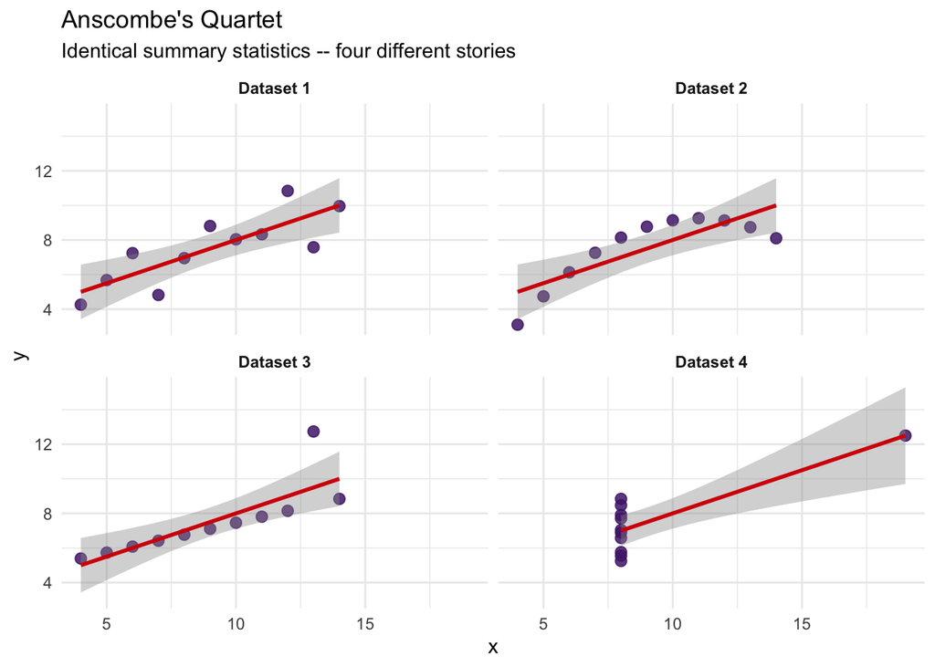

Anscombe’s Quartet: same n, mean, sd, and correlation — four entirely different structures.

```r
anscombe_long |>
  ggplot(aes(x = x, y = y)) +
  geom_point(color = "#502479", size = 2.5, alpha = 0.85) +
  geom_smooth(method = "lm", color = "#D50006",
              se = TRUE, linewidth = 1) +
  facet_wrap(~dataset, nrow = 2) +
  labs(
    title    = "Anscombe's Quartet",
    subtitle = "Identical summary statistics -- four different stories",
    x = "x", y = "y"
  ) +
  theme_minimal(base_size = 11) +
  theme(strip.text = element_text(face = "bold"))
```

**ImportantWhat Each Panel Teaches — and Why It Matters for Regression Diagnostics**

| Panel | Structure | What the OLS line misses | Detected by |
| --- | --- | --- | --- |
| **I** | Linear, roughly homoscedastic | Nothing — OLS is appropriate | Residual plot: random scatter ✓ |
| **II** | Curved (quadratic) relationship | The non-linearity — linear model is structurally wrong | Residual plot: curved pattern |
| **III** | One outlier in *y* | Outlier distorts intercept and slope | Residual plot: one extreme point |
| **IV** | One leverage point (*x* = 19) | Single extreme *x*-value pulls entire line | Residual plot: gap in x-values |

All four problems are diagnosed using the **residual plot** — which you will apply in Lab 3 to detect Omitted Variable Bias.

*The Datasaurus Dozen* (Matejka & Fitzmaurice, 2017) extends the same argument to 13 algorithmically generated datasets with 142 points each (including a dinosaur shape). Anscombe’s quartet is more instructive for a regression course because each panel encodes a *different* diagnostic problem — not just a different visual shape.

### 2.4 Elements of Exploratory Data Analysis

According to @stoetzer_regressionsanalyse_2020, EDA follows four guiding principles:

1. **Substantive meaning** — The primary goal is understanding variables and their plausible relationships, not running formal tests.
2. **Graphical representation** — Visual inspection of variables and distributions is the primary means of gaining insight.
3. **Iterative model building** — The focus is on tentative hypothesis generation in an iterative process of model specification and re-specification.
4. **Scepticism and parsimony** — The starting points are scepticism, flexibility, and restraint regarding which statistical methods to apply.

**NoteEDA as CRISP-DM Phase 2**

In our Carseats project, EDA serves to generate **hypotheses** for the modelling phase: Which variables explain sales differences across stores? Which transformations are necessary? Are there outliers or systematic patterns?

## 3 Step 1: Getting to Know the Dataset

### 3.1 Overview: Structure and Variables

```r
glimpse(tbl_carseats)
```

```
Rows: 400
Columns: 11
$ Sales       <dbl> 9.50, 11.22, 10.06, 7.40, 4.15, 10.81, 6.63, 11.85, 6.54, …
$ CompPrice   <dbl> 138, 111, 113, 117, 141, 124, 115, 136, 132, 132, 121, 117…
$ Income      <dbl> 73, 48, 35, 100, 64, 113, 105, 81, 110, 113, 78, 94, 35, 2…
$ Advertising <dbl> 11, 16, 10, 4, 3, 13, 0, 15, 0, 0, 9, 4, 2, 11, 11, 5, 0, …
$ Population  <dbl> 276, 260, 269, 466, 340, 501, 45, 425, 108, 131, 150, 503,…
$ Price       <dbl> 120, 83, 80, 97, 128, 72, 108, 120, 124, 124, 100, 94, 136…
$ ShelveLoc   <fct> Bad, Good, Medium, Medium, Bad, Bad, Medium, Good, Medium,…
$ Age         <dbl> 42, 65, 59, 55, 38, 78, 71, 67, 76, 76, 26, 50, 62, 53, 52…
$ Education   <dbl> 17, 10, 12, 14, 13, 16, 15, 10, 10, 17, 10, 13, 18, 18, 18…
$ Urban       <fct> Yes, Yes, Yes, Yes, Yes, No, Yes, Yes, No, No, No, Yes, Ye…
$ US          <fct> Yes, Yes, Yes, Yes, No, Yes, No, Yes, No, Yes, Yes, Yes, N…
```

**TipInterpretation**

- How many observations (stores) and variables does the dataset contain?
- Which variables are numeric (`dbl`), which are categorical (`chr`/`fct`)?
- What exactly does `Sales` measure? (Pay attention to the unit!)

### 3.2 Summary Statistics

```r
tbl_carseats |>
  select(Sales, Price, Advertising, Income, Age, ShelveLoc, Urban, US) |>
  skim() |>
  yank("numeric") |>
  gt() |>
  fmt_number(columns = where(is.numeric), decimals = 2) |>
  tab_options(table.font.size = "13px")
```

| skim_variable | n_missing | complete_rate | mean | sd | p0 | p25 | p50 | p75 | p100 | hist |
| --- | --- | --- | --- | --- | --- | --- | --- | --- | --- | --- |
| Sales | 0.00 | 1.00 | 7.50 | 2.82 | 0.00 | 5.39 | 7.49 | 9.32 | 16.27 | ▁▆▇▃▁ |
| Price | 0.00 | 1.00 | 115.79 | 23.68 | 24.00 | 100.00 | 117.00 | 131.00 | 191.00 | ▁▂▇▆▁ |
| Advertising | 0.00 | 1.00 | 6.64 | 6.65 | 0.00 | 0.00 | 5.00 | 12.00 | 29.00 | ▇▃▃▁▁ |
| Income | 0.00 | 1.00 | 68.66 | 27.99 | 21.00 | 42.75 | 69.00 | 91.00 | 120.00 | ▇▆▇▆▅ |
| Age | 0.00 | 1.00 | 53.32 | 16.20 | 25.00 | 39.75 | 54.50 | 66.00 | 80.00 | ▇▆▇▇▇ |

**Caution A1: Explore the Dataset**

1. How many stores (`n`) does the dataset contain?
2. What is the **range** of `Sales` (Min, Max)? What does this mean in practice?
3. What is the **range** of `Price`? Is the car-seat market price-elastic?
4. What does the variable `ShelveLoc` represent? What categories does it have?

```r
tbl_carseats |> count(ShelveLoc)
tbl_carseats |> count(Urban)
tbl_carseats |> count(US)
```

## 4 Step 2: Distribution of the Target Variable Sales

### 4.1 Check Before You Transform

A common reflex in applied work is to log-transform sales data “because sales are always skewed.” **This is wrong as a default.** Whether a transformation is appropriate must be determined from the data — not assumed in advance. That is exactly what EDA is for.

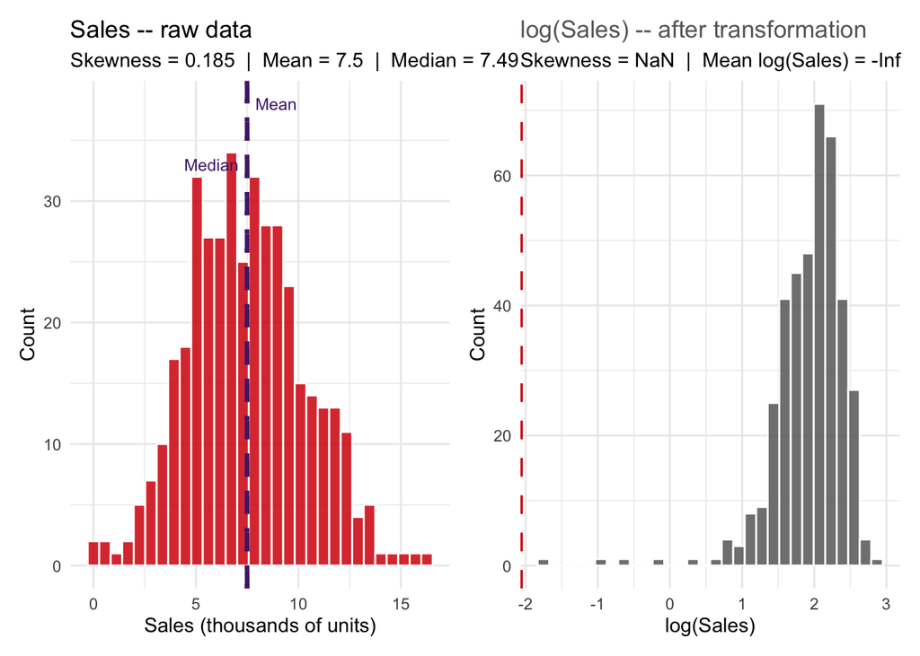

```r
skew_raw <- round(skewness(tbl_carseats$Sales), 3)
skew_log <- round(skewness(log(tbl_carseats$Sales)), 3)

p1 <- tbl_carseats |>
  ggplot(aes(x = Sales)) +
  geom_histogram(bins = 30, fill = "#D50006", color = "white", alpha = 0.85) +
  geom_vline(xintercept = mean(tbl_carseats$Sales),
             color = "#502479", linewidth = 1.2, linetype = "dashed") +
  geom_vline(xintercept = median(tbl_carseats$Sales),
             color = "#502479", linewidth = 1.2, linetype = "dotted") +
  annotate("text", x = mean(tbl_carseats$Sales) + 0.4, y = 38,
           label = "Mean", color = "#502479", size = 3.2, hjust = 0) +
  annotate("text", x = median(tbl_carseats$Sales) - 0.4, y = 33,
           label = "Median", color = "#502479", size = 3.2, hjust = 1) +
  labs(
    title    = "Sales -- raw data",
    subtitle = paste0("Skewness = ", skew_raw,
                      "  |  Mean = ", round(mean(tbl_carseats$Sales), 2),
                      "  |  Median = ", round(median(tbl_carseats$Sales), 2)),
    x = "Sales (thousands of units)", y = "Count"
  ) +
  theme_minimal(base_size = 11)

p2 <- tbl_carseats |>
  ggplot(aes(x = log(Sales))) +
  geom_histogram(bins = 30, fill = "#686868", color = "white", alpha = 0.85) +
  geom_vline(xintercept = mean(log(tbl_carseats$Sales)),
             color = "#D50006", linewidth = 1.2, linetype = "dashed") +
  labs(
    title    = "log(Sales) -- after transformation",
    subtitle = paste0("Skewness = ", skew_log,
                      "  |  Mean log(Sales) = ",
                      round(mean(log(tbl_carseats$Sales)), 3)),
    x = "log(Sales)", y = "Count"
  ) +
  theme_minimal(base_size = 11) +
  theme(plot.title = element_text(color = "#686868"))

p1 + p2
```

**ImportantResult: The Log Transformation Makes Things Worse Here**

The raw `Sales` data are already **approximately symmetric**:

- Skewness of `Sales`: 0.185 — close to zero.
- Mean and Median barely differ.

**Lesson: EDA before transformation — always.** We will work with **untransformed Sales** throughout this course.

**NoteWhen Is a Log Transformation Appropriate?**

The log transformation is theoretically motivated by a **multiplicative generating process**:

$$\text{Sales}_i = \alpha \cdot \text{Price}_i^{\beta_1} \cdot \text{Adv}_i^{\beta_2} \cdot \varepsilon_i$$

Taking logs converts this into an additive, OLS-compatible model whose coefficients are **elasticities**. But the practical precondition — a right-skewed raw distribution — must first be verified empirically.

Contrast: the variable `Advertising` *is* right-skewed (many stores spend nothing; a few spend a lot). A log transformation of `Advertising` would be more defensible. Check this in task A2 below.

**Caution A2: Assess the Distribution**

1. Describe the distribution of `Sales` in your own words. Is it symmetric, right-skewed, or left-skewed? How close are mean and median?
2. Compute skewness for `Sales`, `log(Sales)`, and `Advertising` for comparison:

```r
library(moments)
skewness(tbl_carseats$Sales)
skewness(log(tbl_carseats$Sales))
skewness(tbl_carseats$Advertising)   # this one IS right-skewed -- compare!
```

3. For which variable is a log transformation more justified: `Sales` or `Advertising`? Justify based on the skewness values and histograms.

## 5 Step 3: Bivariate Relationships

### 5.1 Price vs. Sales

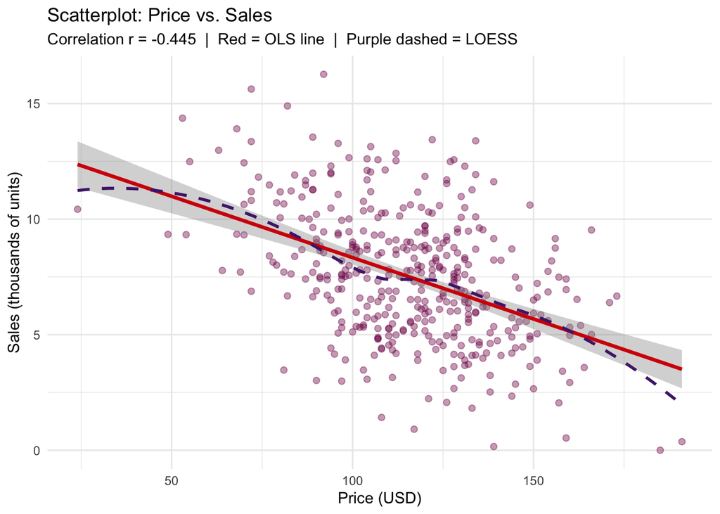

```r
tbl_carseats |>
  ggplot(aes(x = Price, y = Sales)) +
  geom_point(alpha = 0.4, color = "#7d0a52", size = 1.8) +
  geom_smooth(method = "lm", color = "#D50006",
              se = TRUE, linewidth = 1.2) +
  geom_smooth(method = "loess", color = "#502479",
              se = FALSE, linewidth = 1, linetype = "dashed") +
  labs(
    title    = "Scatterplot: Price vs. Sales",
    subtitle = paste0("Correlation r = ",
                      round(cor(tbl_carseats$Price, tbl_carseats$Sales), 3),
                      "  |  Red = OLS line  |  Purple dashed = LOESS"),
    x = "Price (USD)", y = "Sales (thousands of units)"
  ) +
  theme_minimal(base_size = 11)
```

**TipInterpretation**

- What does the correlation say? Is it strong or weak?
- Does the OLS line agree with the LOESS trend? What does that indicate?
- Why is the scatter around the line so high? What is missing from the model?

### 5.2 Scatterplot Matrix: All Variables at Once

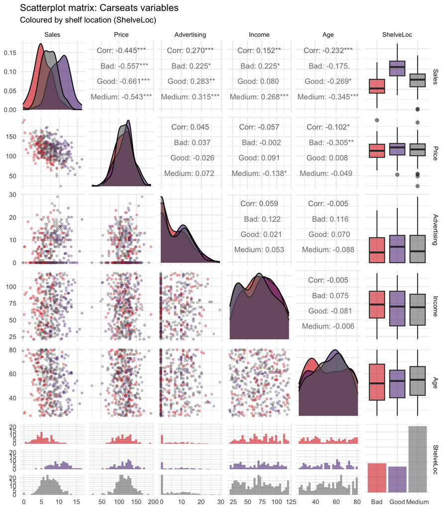

```r
tbl_carseats |>
  select(Sales, Price, Advertising, Income, Age, ShelveLoc) |>
  ggpairs(
    aes(color = ShelveLoc, alpha = 0.5),
    upper = list(continuous = wrap("cor", size = 3)),
    lower = list(continuous = wrap("points", alpha = 0.3, size = 0.8)),
    diag  = list(continuous = wrap("densityDiag", alpha = 0.6))
  ) +
  scale_color_manual(values = c(
    "Bad"    = "#D50006",
    "Medium" = "#686868",
    "Good"   = "#502479"
  )) +
  scale_fill_manual(values = c(
    "Bad"    = "#D50006",
    "Medium" = "#686868",
    "Good"   = "#502479"
  )) +
  theme_minimal(base_size = 9) +
  labs(title    = "Scatterplot matrix: Carseats variables",
       subtitle = "Coloured by shelf location (ShelveLoc)")
```

**NoteGGally::ggpairs() — EDA in One Line of Code**

`ggpairs()` from the `GGally` package produces in a single call:

- **Diagonal:** Distributions of individual variables
- **Upper triangle:** Correlation coefficients
- **Lower triangle:** Scatterplots of all variable pairs

The correlation coefficients in the upper triangle are summary statistics — and as Anscombe showed, summary statistics alone are not enough. Always cross-check with the scatter plots in the lower triangle, which can reveal non-linearities, outliers, or subgroup structure that a single number cannot capture.

**Caution A3: Bivariate Analysis**

1. Which variables correlate **most strongly** with `Sales`? Create a ranked list:

```r
tbl_carseats |>
  select(where(is.numeric)) |>
  cor() |>
  as_tibble(rownames = "variable") |>
  select(variable, Sales) |>
  arrange(desc(abs(Sales)))
```

2. Are there variables strongly correlated **with each other** (multicollinearity risk)? What could this mean for a multiple regression?
3. Describe the relationship between `ShelveLoc` and `Sales` in words. Which category has the highest average sales?

```r
tbl_carseats |>
  group_by(ShelveLoc) |>
  summarise(mean_sales = mean(Sales),
            sd_sales   = sd(Sales),
            n          = n())
```

## 6 Step 4: Formulating Hypotheses

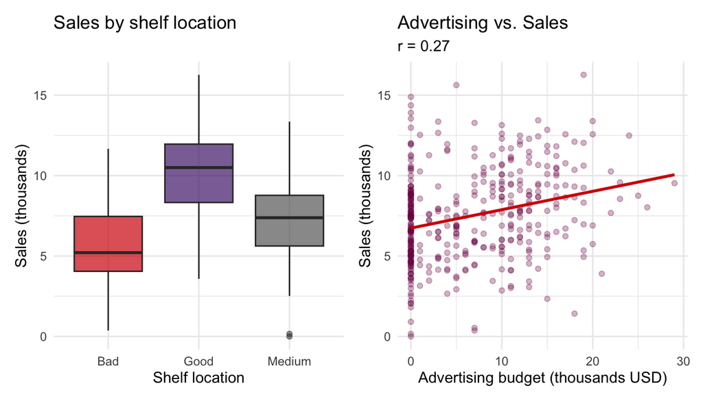

```r
p_shelf <- tbl_carseats |>
  ggplot(aes(x = ShelveLoc, y = Sales, fill = ShelveLoc)) +
  geom_boxplot(alpha = 0.7, outlier.alpha = 0.5) +
  scale_fill_manual(values = c("Bad"    = "#D50006",
                               "Medium" = "#686868",
                               "Good"   = "#502479")) +
  labs(title = "Sales by shelf location",
       x = "Shelf location", y = "Sales (thousands)") +
  theme_minimal(base_size = 11) +
  theme(legend.position = "none")

p_adv <- tbl_carseats |>
  ggplot(aes(x = Advertising, y = Sales)) +
  geom_point(alpha = 0.3, color = "#7d0a52", size = 1.5) +
  geom_smooth(method = "lm", color = "#D50006", se = FALSE) +
  labs(title = "Advertising vs. Sales",
       subtitle = paste0("r = ",
                         round(cor(tbl_carseats$Advertising,
                                   tbl_carseats$Sales), 3)),
       x = "Advertising budget (thousands USD)", y = "Sales (thousands)") +
  theme_minimal(base_size = 11)

p_shelf + p_adv
```

**Caution A4: Hypotheses for Modelling**

Based on your EDA, formulate **two hypotheses** for the goal “Identification of underperforming stores”.

**Example structure:** > *“I expect that [variable X] has a [positive/negative] relationship with Sales, > because [substantive justification].”*

Additionally:

1. For which variable might a **non-linear effect** be plausible?
2. Which variables should **definitely** be included in the regression model? Which probably not — and why?
3. Which variables are **missing** that would be important for explaining sales differences? (Keyword: *Data Drought*, @thomasAIValueCreators2025)
4. **Critical reflection (induction trap):** You have now used all 400 stores to generate these hypotheses. What would need to happen *before exploration* if you wanted to run valid statistical tests afterwards?

## 7 Bonus Tasks

**Tip B1: Estimate Price Elasticity**

Fit a simple log-log regression for exploratory purposes. Note: this is a descriptive exercise — since the hypothesis was generated from the same data, the result is not a valid confirmatory test.

```r
mod_loglog <- tbl_carseats |>
  mutate(log_sales = log(Sales),
         log_price = log(Price)) |>
  lm(log_sales ~ log_price, data = _)

get_regression_table(mod_loglog)
```

- What does the coefficient for `log_price` mean as a price elasticity?
- Compare $R^2$ with the linear model `Sales ~ Price`. What changes?
- Given that `Sales` is not right-skewed: does the log-log specification add value here?

**Tip B2: Outlier Analysis**

```r
tbl_carseats |>
  mutate(rank = dense_rank(desc(Sales))) |>
  filter(rank <= 5 | rank >= (n() - 4)) |>
  select(Sales, Price, Advertising, ShelveLoc, Income, rank) |>
  arrange(rank)
```

Are there stores with extreme price-sales combinations (high price, high sales — or vice versa)?

**Tip B3: Segmented EDA**

```r
tbl_carseats |>
  ggplot(aes(x = Price, y = Sales, color = Urban)) +
  geom_point(alpha = 0.4, size = 1.5) +
  geom_smooth(method = "lm", se = FALSE, linewidth = 1.2) +
  scale_color_manual(values = c("Yes" = "#502479", "No" = "#D50006")) +
  facet_wrap(~US) +
  labs(title = "Price vs. Sales by location (Urban) and region (US)",
       x = "Price (USD)", y = "Sales (thousands)") +
  theme_minimal()
```

Any indications of interaction effects?

## 8 Summary

[output not shown]

**ImportantKey Messages of This Lab**

**NoteTransition to Lab 3**

In Lab 3 we fit the **baseline model** `Sales ~ Price` and examine it critically. A low $R^2$ and a systematic pattern in the residual plot will point to **Omitted Variable Bias** caused by ShelveLoc.

We will also revisit the regression output table and ask: since we are working with a population, what do “estimate”, “std_error”, and “p_value” actually mean here?